# Survival of packages on CRAN

#### Commentary:

In the 2015 data, most of the observations fall into category ‘1’ and ‘0’, then followed by category ‘2’, ‘3’, and ‘4’. The rest of categories are minority, thus in order to reduce the levels of the `Version_new` variable we make them into category ‘others’.

Visualization:

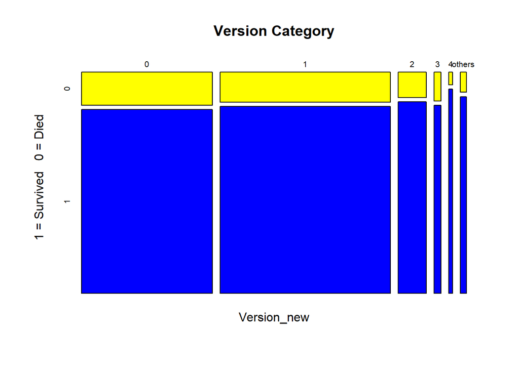

```r
# Mosaic plot of the version category v.s. Survived
with(B.df, mosaicplot(table(Version_new, Survived), col=c("yellow","blue"), main="Version Category", ylab = "1 = Survived   0 = Died"))
```

#### Commentary:

The mosaic plot shows version category ‘4’ has the largest proportion of packages survived, followed by ‘others’, ‘2’; version category ‘1’ and ‘3’ has the similar proportion of packages survived; version category ‘0’ has the lowest proportion of survival. It seems that the updates version (which has higher first numeric component) tend to have higher proportion of survival.

### Dependencies variables: `Depends_on_version` and `Num_Depends`

1. Create a binary `Depends_on_version` for dependencies on a version/versions: we know that there will be parentheses in the variable if the package has dependencies on a version/versions:

```r
# Convert it to 0/1 variable: 0 for non-dependency, 1 for dependency:
B.df$Depends_on_version <- as.factor(as.numeric(grepl("[(]>=", B.df$Depends)))
```

Visualization:

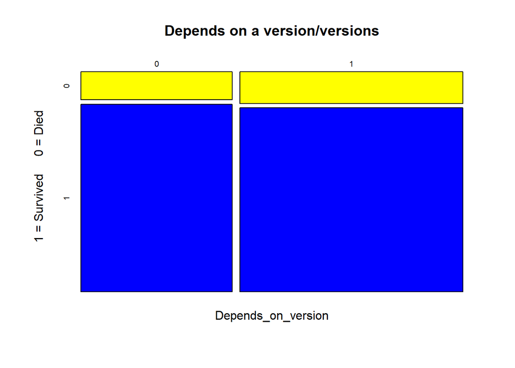

```r
# Mosaic plot of the version  Depends_on_version v.s. Survived
with(B.df, mosaicplot(table(Depends_on_version, Survived), col=c("yellow","blue"), main="Depends on a version/versions", ylab = "1 = Survived     0 = Died"))
```

#### Commentary:

It seems that a package that has no dependency on other a version/versions has a relatively higher probability of survival rate, but that not be significant.

2. Create a variable `Num_Depends` which count the number of dependencies:

```r
# Split the strings:
Depends_split <- strsplit(as.character(B.df$Depends), ",")
# Use gregexpr to count the number of dependences:
B.df$Num_Depends <- sapply((gregexpr("[A-Za-z]{2,}", Depends_split, ignore.case = TRUE)), function(i) sum(i > 0))
```

```r
table(B.df$Num_Depends)
```

```
##
##    0    1    2    3    4    5    6    7    8    9   10   11
## 1538 1441  961  538  405  187   77   20   19    1    2    2
```

Visualization:

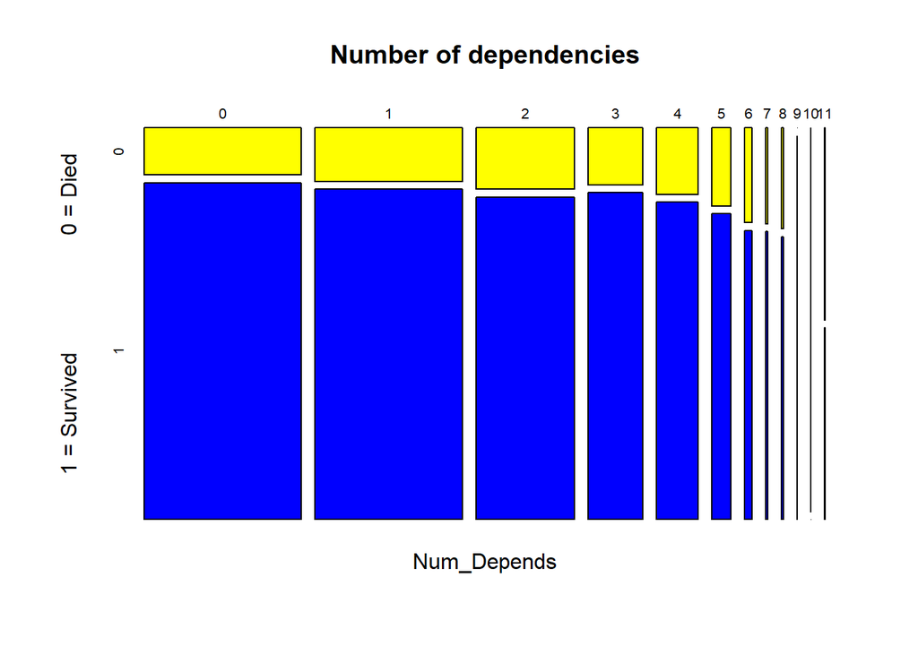

```r
# Mosaic plot of the version Num_Depends v.s. Survived
with(B.df, mosaicplot(table(Num_Depends, Survived), col=c("yellow","blue"), main="Number of dependencies", ylab = "1 = Survived                   0 = Died"))
```

#### Commentary:

The mosaic plot shows that the higher number of dependencies on other packages, the lower the survival probability of a package is.

### License variables: `License_new` & `License_alt`

1. Create a new variable `License_new`, which regroup the license categories.

```r
# Take a look at the frequency table of License
table(B.df$License)
```

```
##
##                          ACM | file LICENSE
##                                           3
##                                        AGPL
##                                           2
##                                      AGPL-3
##                                          20
##                       AGPL-3 | file LICENSE
##                                           2
##                                 AGPL (>= 3)
##                                           3
##                  AGPL (>= 3) + file LICENSE
##                                           1
##                     Apache License (== 2.0)
##                                          16
##      Apache License (== 2.0) | file LICENSE
##                                           3
##                     Apache License (>= 2.0)
##                                           3
##                          Apache License 2.0
##                                          16
##           Apache License 2.0 | file LICENSE
##                                           2
##                                Artistic-2.0
##                                          42
##                        Artistic License 2.0
##                                           4
##                                         BSD
##                                          18
##         BSD 2-clause License + file LICENSE
##                                           2
##                        BSD 3-clause License
##                                           1
##         BSD 3-clause License + file LICENSE
##                                           1
##                 BSD_2_clause + file LICENCE
##                                           1
##                 BSD_2_clause + file LICENSE
##                                          35
##    BSD_2_clause + file LICENSE | GPL (>= 2)
```

[output cut: 198 more lines]

```
##                                           1
##                                     MPL-1.1
##                                           1
##                                MPL (== 1.1)
##                                           1
##                                MPL (== 2.0)
##                                           1
##      MPL (>= 2) | GPL (>= 2) | file LICENSE
##                                           1
##                                MPL (>= 2.0)
##                                           2
##                                   Unlimited
##                                          46
##                    Unlimited | file LICENSE
##                                           1
```

#### Commentary:

In the 2015 data, there are 10 licenses that appear more than 50 times, and 7 of the 10 are GPL-2 or GPL-3 or some combination, which are: `GPL (>= 2)` (with 2631 times), `GPL-2` (with 1451 times), `GPL-3` (with 700 times), `GPL` (with 380 times), `GPL (>= 3)` (with 307 times), `GPL-2 | GPL-3` (with 153 times) and `GPL (>= 2.0)` (with 73 times).

```r
License_new <- as.vector(B.df$License)
# Make "GPL-2", "GPL (>= 2)" and "GPL (>= 2.0)" into "GPL (version 2 or later) Group"
Condition1 <- ifelse(B.df$License == "GPL-2"|B.df$License == "GPL (>= 2)"| B.df$License == "GPL (>= 2.0)", "GPL(V2+) Group", License_new)
# Make "GPL-3" and "GPL (>= 3)" into "GPL (version 3 or later) Group"
Condition2 <- ifelse(B.df$License == "GPL-3"|B.df$License == "GPL (>= 3)", "GPL(V3+) Group", Condition1)
# The rest of high frequency categories remains, but make the low frequency categories into "Others"
Condition3 <- ifelse(
Condition2!="BSD_3_clause + file LICENSE"&Condition2!="GPL"&Condition2!="GPL-2|GPL-3"&Condition2!="LGPL-3"&Condition2!="MIT + file LICENSE"&Condition2!="GPL(V2+) Group"&Condition2!="GPL(V3+) Group",
"Others",
Condition2)
# Create a new variable in the data frame:
B.df$License_new <- Condition3
B.df$License_new <- as.factor(B.df$License_new)
```

```r
table(B.df$License_new)
```

```
##
## BSD_3_clause + file LICENSE                         GPL
##                          59                         380
##              GPL(V2+) Group              GPL(V3+) Group
##                        4155                        1007
##                      LGPL-3          MIT + file LICENSE
##                          72                         236
##                      Others
##                         791
```

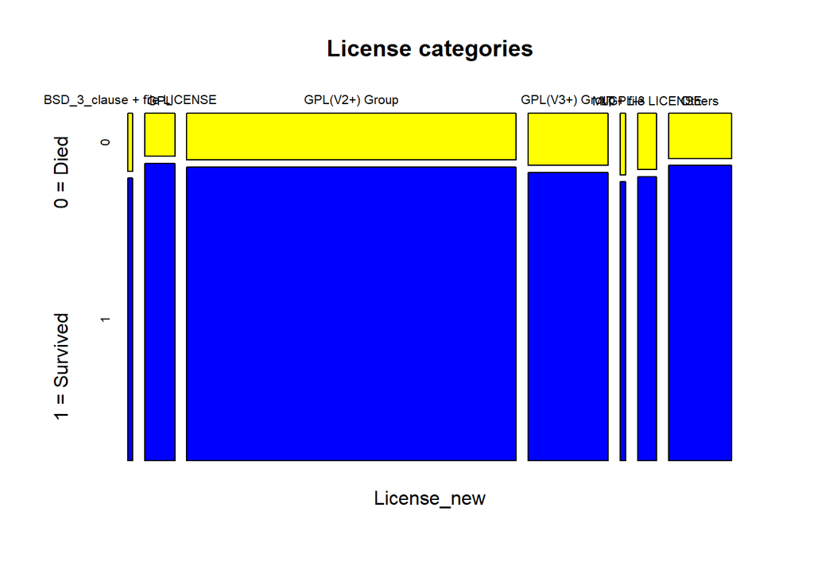

```r
# Mosaic plot of the version Num_Depends v.s. Survived
with(B.df, mosaicplot(table(License_new, Survived), col=c("yellow","blue"), main="License categories", ylab = "1 = Survived                   0 = Died"))
```

2. Create a binary `License_alt` for whether there are alternatives License: we know the strings will be separated by “|” characters characters if there are alternatives.

```r
B.df$License_alt <- as.factor(as.numeric(grepl("[|]", B.df$License)))
```

Visualization:

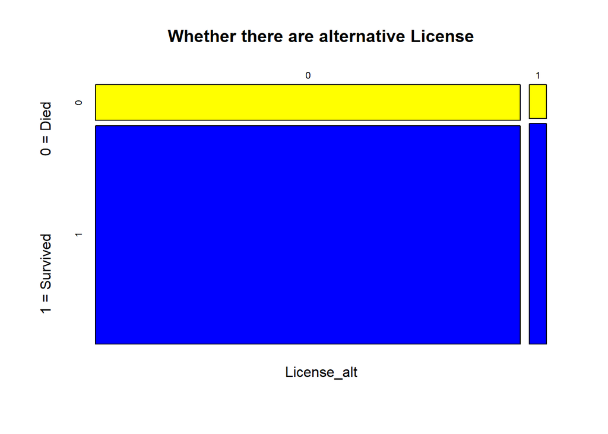

```r
# Mosaic plot of the version License_alt v.s. Survived
with(B.df, mosaicplot(table(License_alt, Survived), col=c("yellow","blue"), main="Whether there are alternative License", ylab = "1 = Survived                   0 = Died"))
```

#### Commentary:

Whether there are alternative license seems affect little on the probability of survival.

## Modelling

Implement the binomial regression model:

```r
# Relevel the License_new
B.df <- within(B.df, License_new <- relevel(License_new, ref = "Others"))
```

```r
mod.bin <- glm(Survived~Version_new+Depends_on_version+Num_Depends+License_new+License_alt, data = B.df, family = binomial(link = "logit"))
summary(mod.bin)
```

```
##
## Call:
## glm(formula = Survived ~ Version_new + Depends_on_version + Num_Depends +
##     License_new + License_alt, family = binomial(link = "logit"),
##     data = B.df)
##
## Deviance Residuals:
##     Min       1Q   Median       3Q      Max
## -2.5272   0.4929   0.5328   0.5870   0.9186
##
## Coefficients:
##                                        Estimate Std. Error z value Pr(>|z|)
## (Intercept)                             1.82245    0.17305  10.531  < 2e-16 ***
## Version_new1                            0.16623    0.08442   1.969  0.04894 *
## Version_new2                            0.42201    0.15951   2.646  0.00815 **
## Version_new3                            0.19286    0.27839   0.693  0.48846
## Version_new4                            1.18153    0.52314   2.259  0.02391 *
## Version_newothers                       0.62104    0.32587   1.906  0.05667 .
## Depends_on_version1                    -0.04633    0.09501  -0.488  0.62585
## Num_Depends                            -0.13170    0.02336  -5.639 1.71e-08 ***
## License_newBSD_3_clause + file LICENSE -0.26746    0.44090  -0.607  0.54410
## License_newGPL                          0.19391    0.22895   0.847  0.39702
## License_newGPL(V2+) Group               0.10454    0.14694   0.711  0.47681
## License_newGPL(V3+) Group              -0.08281    0.16918  -0.490  0.62449
## License_newLGPL-3                      -0.16158    0.35033  -0.461  0.64465
## License_newMIT + file LICENSE          -0.05731    0.26292  -0.218  0.82747
## License_alt1                            0.10877    0.24155   0.450  0.65250
## ---
## Signif. codes:  0 '***' 0.001 '**' 0.01 '*' 0.05 '.' 0.1 ' ' 1
##
## (Dispersion parameter for binomial family taken to be 1)
##
##     Null deviance: 4328.5  on 5184  degrees of freedom
## Residual deviance: 4279.4  on 5170  degrees of freedom
##   (1515 observations deleted due to missingness)
## AIC: 4309.4
##
## Number of Fisher Scoring iterations: 5
```

License doesn’t seem to matter. Number of dependencies does, and version might.

```r
mod.bin2 <- glm(Survived~Version_new+Depends_on_version+Num_Depends, data = B.df, family = binomial(link = "logit"))
summary(mod.bin2)
```

```
##
## Call:
## glm(formula = Survived ~ Version_new + Depends_on_version + Num_Depends,
##     family = binomial(link = "logit"), data = B.df)
##
## Deviance Residuals:
##     Min       1Q   Median       3Q      Max
## -2.4712   0.5048   0.5470   0.5805   0.9203
##
## Coefficients:
##                     Estimate Std. Error z value Pr(>|z|)
## (Intercept)          1.88176    0.10931  17.215  < 2e-16 ***
## Version_new1         0.17206    0.08412   2.045  0.04081 *
## Version_new2         0.42906    0.15892   2.700  0.00694 **
## Version_new3         0.19977    0.27775   0.719  0.47198
## Version_new4         1.18099    0.52199   2.262  0.02367 *
## Version_newothers    0.65099    0.32509   2.002  0.04523 *
## Depends_on_version1 -0.05779    0.09443  -0.612  0.54059
## Num_Depends         -0.12853    0.02318  -5.545 2.94e-08 ***
## ---
## Signif. codes:  0 '***' 0.001 '**' 0.01 '*' 0.05 '.' 0.1 ' ' 1
##
## (Dispersion parameter for binomial family taken to be 1)
##
##     Null deviance: 4328.5  on 5184  degrees of freedom
## Residual deviance: 4284.3  on 5177  degrees of freedom
##   (1515 observations deleted due to missingness)
## AIC: 4300.3
##
## Number of Fisher Scoring iterations: 5
```

It seems that versioned dependencies doesn’t matter much.

```r
mod.bin3 <- glm(Survived~factor(Num_Depends)+Version_new, data = B.df, family = binomial(link = "logit"))
summary(mod.bin3)
```

```
##
## Call:
## glm(formula = Survived ~ factor(Num_Depends) + Version_new, family = binomial(link = "logit"),
##     data = B.df)
##
## Deviance Residuals:
##     Min       1Q   Median       3Q      Max
## -2.4629   0.4992   0.5414   0.5847   1.1774
##
## Coefficients:
##                        Estimate Std. Error z value Pr(>|z|)
## (Intercept)             1.84616    0.08862  20.833  < 2e-16 ***
## factor(Num_Depends)1   -0.16450    0.10924  -1.506 0.132103
## factor(Num_Depends)2   -0.33999    0.11788  -2.884 0.003925 **
## factor(Num_Depends)3   -0.24269    0.14438  -1.681 0.092788 .
## factor(Num_Depends)4   -0.44310    0.15331  -2.890 0.003850 **
## factor(Num_Depends)5   -0.65720    0.19866  -3.308 0.000939 ***
## factor(Num_Depends)6   -0.91293    0.27720  -3.293 0.000990 ***
## factor(Num_Depends)7   -0.85499    0.52323  -1.634 0.102245
## factor(Num_Depends)8   -0.99383    0.52920  -1.878 0.060382 .
## factor(Num_Depends)9    9.58249  324.74412   0.030 0.976460
## factor(Num_Depends)10 -14.41222  229.62849  -0.063 0.949955
## factor(Num_Depends)11  -2.01968    1.41710  -1.425 0.154092
## Version_new1            0.17353    0.08424   2.060 0.039416 *
## Version_new2            0.43022    0.15915   2.703 0.006865 **
## Version_new3            0.19770    0.27805   0.711 0.477063
## Version_new4            1.13741    0.52220   2.178 0.029397 *
## Version_newothers       0.64148    0.32525   1.972 0.048579 *
## ---
## Signif. codes:  0 '***' 0.001 '**' 0.01 '*' 0.05 '.' 0.1 ' ' 1
##
## (Dispersion parameter for binomial family taken to be 1)
##
##     Null deviance: 4328.5  on 5184  degrees of freedom
## Residual deviance: 4277.1  on 5168  degrees of freedom
##   (1515 observations deleted due to missingness)
## AIC: 4311.1
##
## Number of Fisher Scoring iterations: 11
```

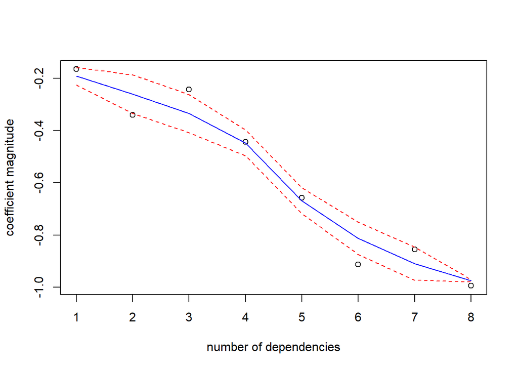

```r
trendscatter(1:8, coef(mod.bin3)[2:9], xlab = "number of dependencies", ylab = "coefficient magnitude",
             main = "")
```

It looks like a linear decrease in general.

```r
B.df$Version_new0<-ifelse(B.df$Version_new %in% c(1, 2, 3, 4), "1-4", B.df$Version_new)
mod.bin4 <- glm(Survived~Num_Depends+Version_new0, data = B.df, family = binomial(link = "logit"))
summary(mod.bin4)
```

```
##
## Call:
## glm(formula = Survived ~ Num_Depends + Version_new0, family = binomial(link = "logit"),
##     data = B.df)
##
## Deviance Residuals:
##     Min       1Q   Median       3Q      Max
## -2.2580   0.4915   0.5465   0.5785   0.8973
##
## Coefficients:
##                 Estimate Std. Error z value Pr(>|z|)
## (Intercept)      1.82581    0.07255  25.168  < 2e-16 ***
## Num_Depends     -0.12279    0.02287  -5.368 7.94e-08 ***
## Version_new01-4  0.22675    0.08034   2.822  0.00477 **
## Version_new06    0.64209    0.32479   1.977  0.04805 *
## ---
## Signif. codes:  0 '***' 0.001 '**' 0.01 '*' 0.05 '.' 0.1 ' ' 1
##
## (Dispersion parameter for binomial family taken to be 1)
##
##     Null deviance: 4328.5  on 5184  degrees of freedom
## Residual deviance: 4291.9  on 5181  degrees of freedom
##   (1515 observations deleted due to missingness)
## AIC: 4299.9
##
## Number of Fisher Scoring iterations: 4
```

The exponentiated estimates for variables:

```r
round(exp(coef(mod.bin4)), 3)
```

```
##     (Intercept)     Num_Depends Version_new01-4   Version_new06
##           6.208           0.884           1.255           1.900
```

The exponentiated confidence intervals for variables:

```r
round(exp(confint(mod.bin4)), 3)
```

```
##                 2.5 % 97.5 %
## (Intercept)     5.394  7.168
## Num_Depends     0.846  0.925
## Version_new01-4 1.071  1.468
## Version_new06   1.051  3.800
```

## Summary

License doesn’t seem to be related to package survival. Packages with more dependences were less likely to survive, by a factor of 0.88 per dependency; versioned dependencies didn’t matter much.

Packages in version 0 were the least likely to have survived. Those with numeric versions starting 1, 2, 3, and 4 were about 1.26 as likely, and those with other numbering schemes were substantially more likely (probably because these represented people with pre-existing versioning policies from experience with programming).

# Task Three

## Describe how dependencies, and license relate to the subsequent survival time of a package on CRAN in 2015

## Data Cleaning

```r
# Rename the column in B.df to make it consistent with all_dates'
colnames(B.df)[1] <- "pkg"
```

```r
# Combine the 2 data frame into one:
combined.df <- merge(all_dates, B.df, all=TRUE)
# Delete those records 'Survived' information is NA:
combined.df <- subset(combined.df, !is.na(Survived))
```

## Modelling

Implement the Cox model:

```r
modelcox1 <- coxph(Surv(end_date - as.numeric(as.Date("2015-06-02")), Survived==0)~Version_new+Depends_on_version+Num_Depends+License_new+License_alt, data=combined.df)
modelcox1
```

```
## Call:
## coxph(formula = Surv(end_date - as.numeric(as.Date("2015-06-02")),
##     Survived == 0) ~ Version_new + Depends_on_version + Num_Depends +
##     License_new + License_alt, data = combined.df)
##
##                                            coef exp(coef) se(coef)      z
## Version_new1                           -0.14449   0.86547  0.07743 -1.866
## Version_new2                           -0.39177   0.67586  0.14875 -2.634
## Version_new3                           -0.17755   0.83732  0.25656 -0.692
## Version_new4                           -1.12001   0.32628  0.50458 -2.220
## Version_newothers                      -0.56714   0.56714  0.30762 -1.844
## Depends_on_version1                     0.02651   1.02686  0.08738  0.303
## Num_Depends                             0.12275   1.13060  0.02109  5.821
## License_newBSD_3_clause + file LICENSE  0.16927   1.18443  0.39862  0.425
## License_newGPL                         -0.21066   0.81005  0.21188 -0.994
## License_newGPL(V2+) Group              -0.11482   0.89153  0.13469 -0.852
## License_newGPL(V3+) Group               0.04087   1.04172  0.15463  0.264
## License_newLGPL-3                       0.02178   1.02202  0.32780  0.066
## License_newMIT + file LICENSE           0.02111   1.02133  0.24111  0.088
## License_alt1                           -0.13097   0.87724  0.22245 -0.589
##                                               p
## Version_new1                            0.06204
## Version_new2                            0.00845
## Version_new3                            0.48892
## Version_new4                            0.02644
## Version_newothers                       0.06523
## Depends_on_version1                     0.76163
## Num_Depends                            5.84e-09
## License_newBSD_3_clause + file LICENSE  0.67111
## License_newGPL                          0.32011
## License_newGPL(V2+) Group               0.39395
## License_newGPL(V3+) Group               0.79152
## License_newLGPL-3                       0.94702
## License_newMIT + file LICENSE           0.93024
## License_alt1                            0.55603
##
## Likelihood ratio test=49.46  on 14 df, p=7.503e-06
## n= 5184, number of events= 761
##    (1516 observations deleted due to missingness)
```

```r
modelcox2 <-coxph(Surv(end_date - as.numeric(as.Date("2015-06-02")), Survived==0)~Version_new0+Num_Depends, data=combined.df)
modelcox2
```

```
## Call:
## coxph(formula = Surv(end_date - as.numeric(as.Date("2015-06-02")),
##     Survived == 0) ~ Version_new0 + Num_Depends, data = combined.df)
##
##                     coef exp(coef) se(coef)      z        p
## Version_new01-4 -0.20069   0.81817  0.07377 -2.720  0.00652
## Version_new06   -0.58608   0.55650  0.30679 -1.910  0.05608
## Num_Depends      0.11525   1.12216  0.02067  5.577 2.45e-08
##
## Likelihood ratio test=37.4  on 3 df, p=3.785e-08
## n= 5184, number of events= 761
##    (1516 observations deleted due to missingness)
```

## Summary

The hazard ratio for `Num_Depends` is 1.122, so packages with a 1 number higher in the dependency on other packages had a 12.2% higher rate (hazard) of death (on average, over the follow-up time).

In conclusion, the Cox model gives a very similar message to the logistic model. The coefficients have similar magnitudes (but opposite signs) and so do the standard errors.